# Analysis of NYPD Crime Data

#### *Benjamin Margolin and Surya Udayshankar*

### Introduction

The analysis of NYPD crime data is important because it provides insights into crime trends, patterns, and demographics in New York City. By examining historical arrest records, we can better understand the dynamics of criminal activity across different neighborhoods and among various demographic groups. This understanding is essential for law enforcement agencies, policymakers, and community organizations to develop effective strategies for crime prevention, resource allocation, and public safety enhancement.

Crime analysis is particularly relevant in today's context as cities continue to face challenges related to crime and public safety. With the availability of detailed historical data from the NYPD, we have the opportunity to perform comprehensive analyses that can uncover underlying patterns and trends. Our project encompasses multiple stages of the data science pipeline, including data curation, parsing, and management; exploratory data analysis; hypothesis testing and machine learning. Through this approach, we aim to not only describe past and present crime trends but also forecast future crime rates. This combination of retrospective analysis and predictive insights can inform proactive measures and policies, ultimately contributing to a safer urban environment.

### Hypothesis

We suspect that different ages, genders, races, locations, and crime law categories have experienced unproportional changes in arrest rates over time.

### Data Collection and Processing

To start the data science pipeline, we look for a dataset to make the necessary analysis. We will use the NYPD Crime Data (Historical) dataset on the [U.S. Government's Open Data website](https://catalog.data.gov/dataset/nypd-arrests-data-historic). The dataset includes a list of every arrest from 2006 to 2023 in NYC. The list provides a breakfown down of each crime and suspect demographics.

The libraries we'll be using:

[NumPy](https://numpy.org/) (numpy): A fundamental package for scientific computing with Python, used for array processing and numerical operations.

[Pandas](https://pandas.pydata.org/) (pandas): A powerful data manipulation and analysis library that provides data structures like DataFrames to efficiently handle and analyze structured data. Matplotlib (matplotlib.pyplot): A plotting library used for creating static, interactive, and animated visualizations in Python, essential for data visualization and exploratory data analysis.

[Folium](https://python-visualization.github.io/folium/latest/_) (folium): A library that makes it easy to visualize data that's been manipulated in Python on an interactive Leaflet map. It is particularly useful for plotting geographic data.

[Folium HeatMap Plugin](https://python-visualization.github.io/folium/latest/user_guide/plugins/heatmap.html) (folium.plugins.HeatMap): A plugin for Folium that allows for the creation of heatmaps, which are useful for visualizing the intensity of geographic data points.

[sklearn](https://scikit-learn.org/stable/) (scikit-learn): A machine learning library in Python that provides simple and efficient tools for data mining and data analysis, supporting various supervised and unsupervised learning algorithms.

[scipy.stats](https://docs.scipy.org/doc/scipy/reference/stats.html): A module for statistical functions and distributions, including correlation functions like Pearson correlation.

[tensorflow](https://www.tensorflow.org/) (TensorFlow): An open-source platform for machine learning and artificial intelligence, providing comprehensive tools for building and training deep learning models.

```python
import numpy as np
import pandas as pd
import matplotlib.pyplot as plt
import folium
from folium.plugins import HeatMap

from sklearn.model_selection import train_test_split
from sklearn.metrics import mean_squared_error
from sklearn.linear_model import SGDRegressor
from sklearn.preprocessing import OneHotEncoder, StandardScaler, PolynomialFeatures, MinMaxScaler
from sklearn.pipeline import Pipeline

from scipy.stats import pearsonr

import tensorflow as tf
from tensorflow.keras.models import Sequential
from tensorflow.keras.layers import Dense, LSTM
import math
```

```python
df = pd.read_csv('NYPD_Arrests_Data__Historic_.csv')
```

```python
df.head()
```

|  | ARREST_KEY | ARREST_DATE | PD_CD | PD_DESC | KY_CD | OFNS_DESC | LAW_CODE | LAW_CAT_CD | ARREST_BORO | ARREST_PRECINCT | JURISDICTION_CODE | AGE_GROUP | PERP_SEX | PERP_RACE | X_COORD_CD | Y_COORD_CD | Latitude | Longitude | Lon_Lat |
| --- | --- | --- | --- | --- | --- | --- | --- | --- | --- | --- | --- | --- | --- | --- | --- | --- | --- | --- | --- |
| 0 | 220756993 | 11/19/2020 | 155.0 | RAPE 2 | 104.0 | RAPE | PL 1303001 | F | B | 41 | 0.0 | 18-24 | M | BLACK | 1013232.0 | 236725.0 | 40.816392 | -73.895296 | POINT (-73.89529641399997 40.816391847000034) |
| 1 | 221995093 | 12/18/2020 | 177.0 | SEXUAL ABUSE | 116.0 | SEX CRIMES | PL 1306503 | F | K | 84 | 0.0 | 45-64 | M | WHITE | 989013.0 | 192652.0 | 40.695469 | -73.982825 | POINT (-73.98282507899995 40.69546894100006) |
| 2 | 221558560 | 12/09/2020 | 157.0 | RAPE 1 | 104.0 | RAPE | PL 1303501 | F | S | 120 | 0.0 | <18 | M | BLACK | 962748.0 | 174174.0 | 40.644726 | -74.077483 | POINT (-74.07748315899995 40.64472613100002) |
| 3 | 217890363 | 09/15/2020 | NaN | NaN | NaN | NaN | PL 2650022 | M | B | 44 | 0.0 | 25-44 | M | BLACK | 1009412.0 | 245306.0 | 40.839956 | -73.909065 | POINT (-73.90906496999997 40.83995593800007) |
| 4 | 219517698 | 10/21/2020 | 153.0 | RAPE 3 | 104.0 | RAPE | PL 1302502 | F | Q | 112 | 0.0 | 25-44 | M | WHITE HISPANIC | 1025420.0 | 202485.0 | 40.722364 | -73.851474 | POINT (-73.85147389399998 40.72236368700004) |

### Data Cleaning

First we must clean the data. The data is very complete as this are government records. After thorough inspection of the data we concluded that any NaN values present in the dataframe were MCAR (Missing Completely at Random). This can be from various causes such as accidental data loss when bookeeping or typos. Because of this we concluded it is safe to drop any rows containing NaN data.

During the data cleaning process it is also important to get rid of clutter and variables that will not be used later in the process. This doesn't always have to be done in the begining because you don't always know what data you will be working with or may need later in the project. In our case, as you can see below we drop the columns that we didn't use such as 'PD_CD', 'PD_DESC', etc. This is done using pandas' .drop() method which is called on a dataframe.

The next important step in processing your data is making sure it is in an easy to work with format. Our dataframe contains only strings which is common when reading in data from a CSV. It is particularly inconvenient to work with dates as strings. Fortunately, pandas has a built in method called pd.to_datetime(). This allows us to more easily work with dates and even compare dates with '< > == '.

```python
# clean up data

# drop na values
df = df.dropna()

# convert date to datetime
df['ARREST_DATE'] = pd.to_datetime(df['ARREST_DATE'])

# drop columns that are not needed
df = df.drop(columns=['PD_CD', 'PD_DESC', 'KY_CD', 'LAW_CODE', 'ARREST_PRECINCT', 'JURISDICTION_CODE', 'X_COORD_CD', 'Y_COORD_CD', 'Lon_Lat'])


# Extract year and month
df['Year'] = df['ARREST_DATE'].dt.year
df['Month'] = df['ARREST_DATE'].dt.month
```

### Exploratory Data Analysis

In this section, we will perform exploratory data analysis (EDA) to uncover trends and patterns within our dataset. By analyzing various subcategories such as the type of crime, location, and suspect demographics, we can gain valuable insights that help us understand the underlying factors influencing crime rates.

Lets start by ploting the total number of arrests over time.

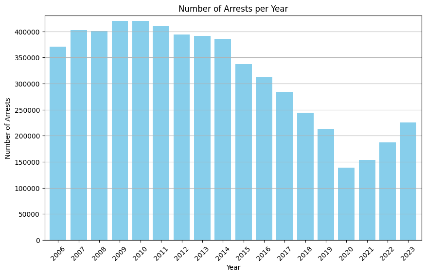

```python
# number of arrests over time

# calculate number of arrests per year
arrests_per_year = df['ARREST_DATE'].dt.year.value_counts().sort_index()

plt.figure(figsize=(10, 6))

bar_width = .8
arrests_per_year.plot(kind='bar', width=bar_width, color = 'skyblue')

plt.title('Number of Arrests per Year')
plt.xlabel('Year')
plt.ylabel('Number of Arrests')
plt.xticks(rotation=45)
plt.grid(axis = 'y')

# set y-axis to start at 0
plt.ylim(0, arrests_per_year.max() + 10000)

plt.show()
```

As you can see, the number of arrest have been generally descreasing until 2020 where there was a more significant drop in arrests. After 2020, the rates have been increasing. We can assume that this drop in 2020 can be attributed to the COVID-19 pandemic. Another important factor that we believe may have strongly contributed to the decline of crime from around 2014 to 2020 is the unconstitutionalization of [stop-and-frisk](https://www.law.cornell.edu/wex/stop_and_frisk) in January of 2014. Stop-and-frisk was the practice of detaining, searching, and questioning individuals who seemed suspicious but hadn't commited any crimes yet. Thus, officers didn't need probable cause, all they needed was reasonable suspicion. One more factor that we believe could have led to the decline in arrest rates from around 2014 to 2020 was the [legalization of medical marijuana](https://www.ncbi.nlm.nih.gov/pmc/articles/PMC6358421/) in 2016.

The most important knowledge we have gained from this plot though is that if we plan on predicting arrest rates in the future, past 2023, we should only use data from 2020 onwards because it is clear that there have been drastic changes affecting rates of arrests, like legal changes and the pandemic.

Now we should see if the crime trends differ between different groups of people, so let's continue by visualizing the number of arrests by different suspect demographic categories. We'll start with graphing number of arrests by race.

### Race

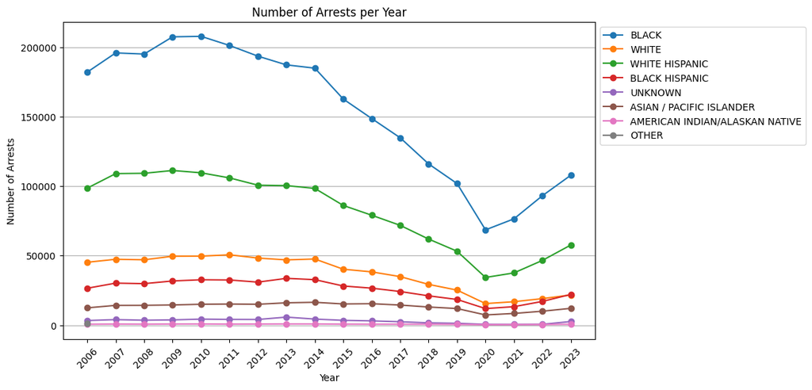

```python
# plot all races on the same plot
plt.figure(figsize=(10, 6))

for race in df['PERP_RACE'].unique():
    df_race = df[df['PERP_RACE'] == race]
    arrests_per_year = df_race['ARREST_DATE'].dt.year.value_counts().sort_index()
    plt.plot(arrests_per_year.index, arrests_per_year.values, marker = 'o', label = race)


plt.title('Number of Arrests per Year')
plt.xlabel('Year')
plt.ylabel('Number of Arrests')
plt.xticks(rotation=45)
plt.xticks(np.arange(2006, 2024, 1))
plt.grid(axis = 'y')
# plt.legend()
plt.legend(bbox_to_anchor=(1, 1), loc='upper left')
```

The trend of arrest rates between each race is similar to that of the total number of arrests, which is signified by the general decrease until 2020, the drop at 2020, and the general increase after 2020. Let's see if there's a different between different sexes.

### Gender

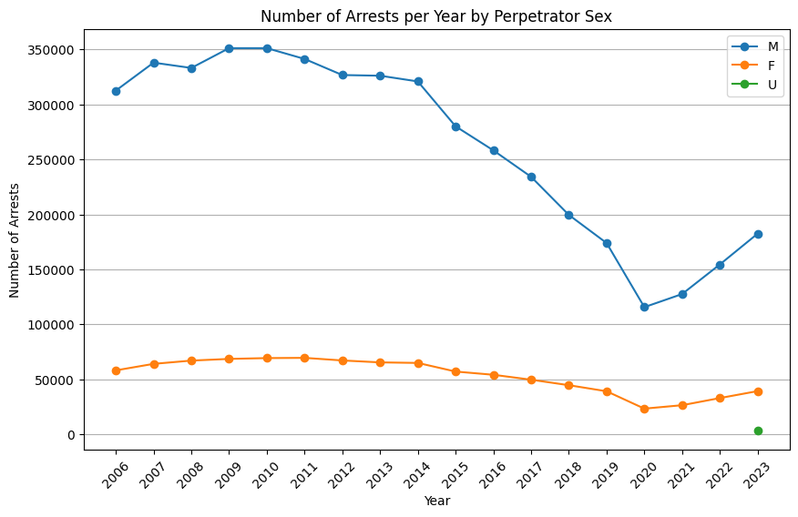

```python
# plot arrest rates over time by gender

plt.figure(figsize=(10, 6))

for sex in df['PERP_SEX'].unique():
    df_sex = df[df['PERP_SEX'] == sex]
    arrests_per_year = df_sex['ARREST_DATE'].dt.year.value_counts().sort_index()
    plt.plot(arrests_per_year.index, arrests_per_year.values, marker='o', label=sex)

plt.title('Number of Arrests per Year by Perpetrator Sex')
plt.xlabel('Year')
plt.ylabel('Number of Arrests')
plt.xticks(rotation=45)
plt.xticks(np.arange(2006, 2024, 1))
plt.grid(axis='y')
plt.legend()
plt.show()
```

The sexes shown in the graph also exhibit the same trend as the total arrests rates graph. The trend is especially similar post 2020. It is important to note things like this because had arrest rates for males gone up but arrest rates for females gone down, we would have to break them out into two different models because if we grouped them into the same models the trends would supress each other and we wouldn't see the underlying trends. Let's see if there's a difference in the arrest trends between the different [boroughs of NYC](https://en.wikipedia.org/wiki/Boroughs_of_New_York_City).

### Location

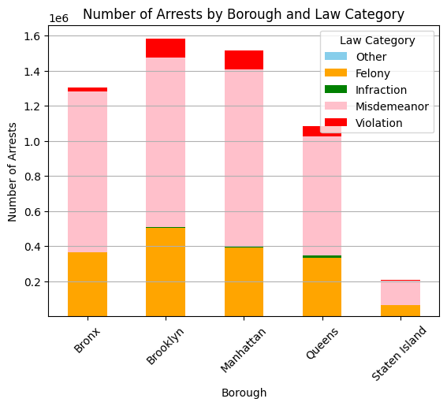

```python
# number of arrests by borough and law category

# Mapping single-letter labels to full names
borough_mapping = {
    'B': 'Bronx',
    'K': 'Brooklyn',
    'M': 'Manhattan',
    'Q': 'Queens',
    'S': 'Staten Island'
}

# Mapping law category codes to full names
law_category_mapping = {
    'F': 'Felony',
    'M': 'Misdemeanor',
    'V': 'Violation',
    'I': 'Infraction',
    '9': 'Other'
}


# Make a bar plot of the number of arrests by borough and law category
arrests_by_borough = df.pivot_table(index='ARREST_BORO',
                                    columns='LAW_CAT_CD',
                                    values='ARREST_KEY',
                                    aggfunc='count')

# Plot the data
ax = arrests_by_borough.plot(kind='bar', stacked=True, color=['skyblue', 'orange', 'green', 'pink', 'red'])

# Add title and labels
plt.title('Number of Arrests by Borough and Law Category')
plt.xlabel('Borough')
plt.ylabel('Number of Arrests')

# Change x-axis labels to full borough names
plt.xticks(ticks=range(len(arrests_by_borough.index)),
           labels=[borough_mapping[borough] for borough in arrests_by_borough.index],
           rotation=45)

# Modify the legend to show full names
handles, labels = ax.get_legend_handles_labels()
labels = [law_category_mapping[label] for label in labels]
ax.legend(handles, labels, title='Law Category')

# Add gridlines to the y-axis
plt.grid(axis='y')

# Show the plot
plt.show()
```

It appears that there are some substatial differences here. Lets see if the boroughs also experience different arrest rate trends over time from factors such as different policymaking.

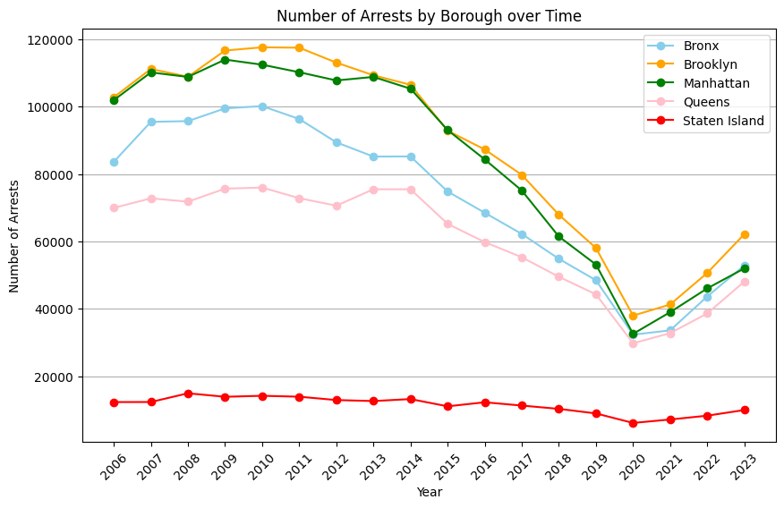

```python
# plot number of arrests by borough over time

# Mapping abbreviations to full borough names
borough_mapping = {
    'B': 'Bronx',
    'K': 'Brooklyn',
    'M': 'Manhattan',
    'Q': 'Queens',
    'S': 'Staten Island'
}

# plot number of arrests by borough over time
arrests_by_borough = df.pivot_table(index = df['ARREST_DATE'].dt.year,
                                    columns = 'ARREST_BORO',
                                    values = 'ARREST_KEY',
                                    aggfunc = 'count')

arrests_by_borough.plot(kind='line', color = ['skyblue', 'orange', 'green', 'pink', 'red'], marker = 'o', figsize=(10, 6))

plt.title('Number of Arrests by Borough over Time')
plt.xlabel('Year')
plt.ylabel('Number of Arrests')
plt.xticks(rotation=45)
plt.grid(axis = 'y')
plt.xticks(np.arange(2006, 2024, 1))

# Get current legend
handles, labels = plt.gca().get_legend_handles_labels()

# Replace labels
labels = [borough_mapping[label] for label in labels]

# Set the legend
plt.legend(handles, labels)

plt.show()
```

It appears that although type of crime is different from borough to borough that arrest rates (which is what we will be predicting) actually do follow the same trend. This came to us as a bit of a surprise because we figured that the different boroughs would have reacted differently to the factors that affect arrest rates. These factors include the events we discussed earlier, such as the end of stop and frisk and the COVID-19 pandemic.

### Age

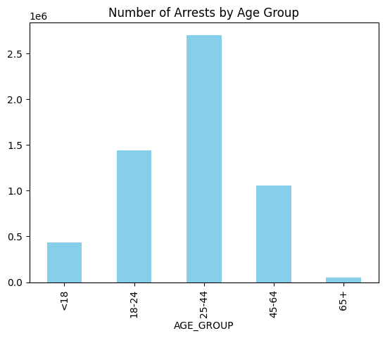

```python
# plot number of arrest by age group

# find out how many values are '18-24' in age groups
age_groups = df['AGE_GROUP'].value_counts()

# Define the order of age groups
age_order = ['<18', '18-24', '25-44', '45-64', '65+']

# Reindex the age_groups Series with the desired order
age_groups = age_groups.reindex(age_order)

# age_groups = age_groups.loc[['<18', '18-24', '25-44', '45-64', '65+']]
age_groups.plot(kind='bar', color = 'skyblue')

plt.title('Number of Arrests by Age Group')
```

As you can see, the dataset of arrest data show that the 25-44 age range have committed the most crimes in our time period of 2006-2023. While we can make that conclusion, we still don't know if these different age ranges show a different trend over time compared to each other and the total arrests by year graph. Let's make a different plot that shows arrest across different age groups over time.

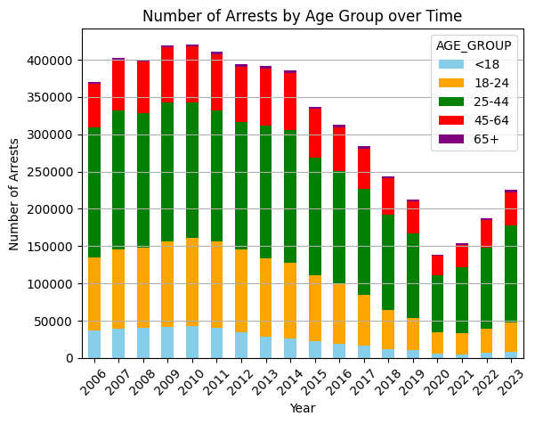

```python
# now lets see if it has always been like this or if it changes over time
# plot number of arrests by age group over time

# create a pivot table
arrests_by_age = df.pivot_table(index = df['ARREST_DATE'].dt.year,
                                columns = 'AGE_GROUP',
                                values = 'ARREST_KEY',
                                aggfunc = 'count')

arrests_by_age = arrests_by_age.reindex(columns = age_order)

arrests_by_age.plot(kind='bar', stacked=True, color = ['skyblue', 'orange', 'green', 'red', 'purple'])

plt.title('Number of Arrests by Age Group over Time')
plt.xlabel('Year')
plt.ylabel('Number of Arrests')
plt.xticks(rotation=45)
plt.grid(axis = 'y')

# plot number
plt.show()
```

### Type of Crime

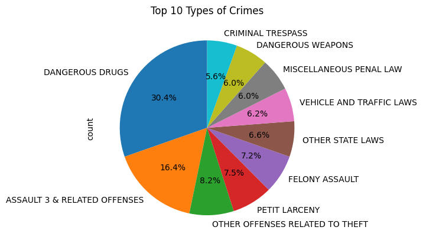

```python
# make a pie chart of the top 10 types of crimes

top_crimes = df['OFNS_DESC'].value_counts().head(10)

top_crimes.plot(kind='pie', autopct='%1.1f%%', startangle=90, shadow=False, legend=False)

plt.title('Top 10 Types of Crimes')

plt.show()
```

We can observe that "Dangerous Drugs" can be attributed for the largest portion of arrests over the time period, with "Assualt 3 and Reltaed Offenses" with the second largest. Let's see what trends for each type of crime over time looks like.

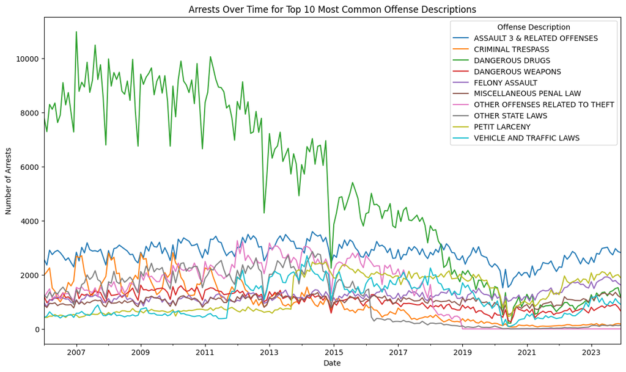

```python
# Identify the top 10 most common offense descriptions
top_offenses = df['OFNS_DESC'].value_counts().head(10).index

# Filter the DataFrame to include only these top offenses
df_top_offenses = df[df['OFNS_DESC'].isin(top_offenses)]

# Group the data by offense description and date to count arrests
df_grouped = df_top_offenses.groupby(['OFNS_DESC', df['ARREST_DATE'].dt.to_period('M')]).size().unstack(fill_value=0)

# Plot the data
df_grouped.T.plot(figsize=(14, 8), title='Arrests Over Time for Top 10 Most Common Offense Descriptions')
plt.xlabel('Date')
plt.ylabel('Number of Arrests')
plt.legend(title='Offense Description')
plt.show()
```

The trend for each type of crime are similar to each other and the properties of the total arrests over time graph, which we discussed. Let's see what graph looks like when we only focus on half way through 2020 and onwards. This will help us visualize the part of the data that we plan to train our model on. We will also be able to see if any of the trends behave differently. We initially hypothesized that they would indeed behave differently due to things like improved average quality of life making people less prone to robbery. Another thing to note about the graph above is we can now see more clearly what we believe is the impact of legalizing marijuana in 2016.

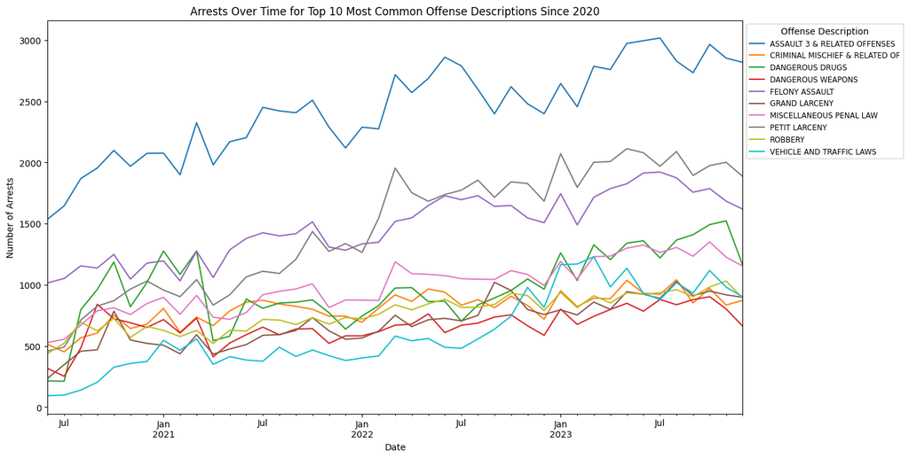

```python
# now plot that only since mid 2020

df_since_2020 = df[df['ARREST_DATE'] >= '2020-06-01']

# Identify the top 10 most common offense descriptions since 2020
top_offenses_since_2020 = df_since_2020['OFNS_DESC'].value_counts().head(10).index

# Filter the DataFrame to include only these top offenses
df_top_offenses_since_2020 = df_since_2020[df_since_2020['OFNS_DESC'].isin(top_offenses_since_2020)]

# Group the data by offense description and date to count arrests
df_grouped_since_2020 = df_top_offenses_since_2020.groupby(['OFNS_DESC', df['ARREST_DATE'].dt.to_period('M')]).size().unstack(fill_value=0)

# Plot the data
df_grouped_since_2020.T.plot(figsize=(14, 8), title='Arrests Over Time for Top 10 Most Common Offense Descriptions Since 2020')
plt.xlabel('Date')
plt.ylabel('Number of Arrests')
plt.legend(title='Offense Description', fontsize='small', bbox_to_anchor=(1, 1))
plt.show()
```

Not all types of crime follows the same general increase. This shows us that it would be a good idea to model each of these separately as some increase quite a lot while others appear to be almost flat. Now let's see if there's a difference in the trends of [felonies, misdemeanors, infractions, and violations](https://www.nolo.com/legal-encyclopedia/crimes-felonies-misdemeanors-infractions-classification-33814.html) over time.

### Law Category

```python
# create a pivot table
arrests_by_law_cat = df.pivot_table(index = df['ARREST_DATE'].dt.year,
                                    columns = 'LAW_CAT_CD',
                                    values = 'ARREST_KEY',
                                    aggfunc = 'count')
arrests_by_law_cat
```

| LAW_CAT_CD ARREST_DATE | 9 | F | I | M | V |
| --- | --- | --- | --- | --- | --- |
| 2006 | NaN | 103299.0 | 2040.0 | 245487.0 | 19947.0 |
| 2007 | NaN | 108616.0 | 4234.0 | 265450.0 | 23822.0 |
| 2008 | NaN | 105787.0 | 2195.0 | 267617.0 | 24673.0 |
| 2009 | NaN | 101058.0 | 2216.0 | 287217.0 | 29325.0 |
| 2010 | NaN | 97473.0 | 1890.0 | 291647.0 | 29545.0 |
| 2011 | NaN | 94087.0 | 1711.0 | 285720.0 | 29420.0 |
| 2012 | NaN | 92668.0 | 1714.0 | 270752.0 | 28812.0 |
| 2013 | NaN | 95559.0 | 2076.0 | 264075.0 | 29876.0 |
| 2014 | NaN | 94532.0 | 2399.0 | 258855.0 | 30089.0 |
| 2015 | NaN | 91352.0 | 1717.0 | 219383.0 | 24741.0 |
| 2016 | NaN | 94182.0 | 1603.0 | 205976.0 | 10642.0 |
| 2017 | NaN | 88900.0 | 1125.0 | 188072.0 | 5756.0 |
| 2018 | NaN | 86195.0 | 723.0 | 154265.0 | 3015.0 |
| 2019 | NaN | 83244.0 | 433.0 | 126590.0 | 2822.0 |
| 2020 | NaN | 65264.0 | 182.0 | 72992.0 | 549.0 |
| 2021 | NaN | 70821.0 | 230.0 | 82575.0 | 385.0 |
| 2022 | NaN | 84988.0 | 237.0 | 101435.0 | 797.0 |
| 2023 | 611.0 | 98608.0 | 246.0 | 124479.0 | 1312.0 |

```python
# drop the '9' column from the main dataframe as it only has data for one year
df = df[df['LAW_CAT_CD'] != '9']
arrests_by_law_cat = df.pivot_table(index = df['ARREST_DATE'].dt.year,
                                    columns = 'LAW_CAT_CD',
                                    values = 'ARREST_KEY',
                                    aggfunc = 'count')
```

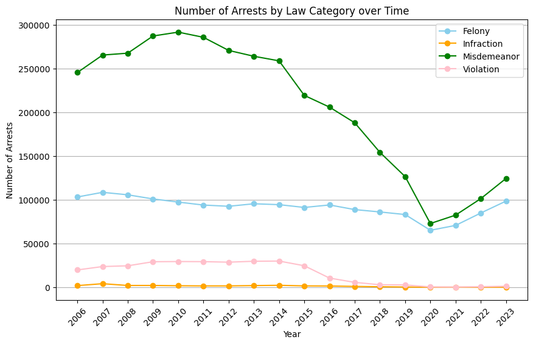

```python
# line plot of felonies, misdemeanors, and violations over time

# Mapping single-letter labels to full names
law_cat_mapping = {
    'F': 'Felony',
    'I': 'Infraction',
    'M': 'Misdemeanor',
    'V': 'Violation'
}

# line plot of felonies, misdemeanors, and violations over time
arrests_by_law_cat.plot(kind='line', color = ['skyblue', 'orange', 'green', 'pink'], marker = 'o', figsize=(10, 6))

plt.title('Number of Arrests by Law Category over Time')
plt.xlabel('Year')
plt.ylabel('Number of Arrests')
plt.xticks(rotation=45)
plt.grid(axis = 'y')
plt.xticks(np.arange(2006, 2024, 1))

# Get current legend
handles, labels = plt.gca().get_legend_handles_labels()

# Replace labels
labels = [law_cat_mapping[label] for label in labels]

# Set the legend
plt.legend(handles, labels)

plt.show()
```

This is interesting, there is a huge drop in misdemeanors. We beliebe this can be attributed to once again the legalization of marijuana but more importantly the end of the stop and frisk period. However, since we are focusing on predicting future arrest rates we will only focus on post 2020 data. When taking a look at that we see that felonies and misdemeanors follow the same increasing trend. Infractions (I) and Violations (V) also go to zero as New York has basically done away with them after the stop and frisk era.

# Machine Learning

Now that we have done our data exploration we have concluded that age, gender, race, location, and crime law category all exhibit the same trends after 2020. This means that we don't need to handle them as seperate cases because they will not contradict each other.

This suggests that the most substantial variable to use to predict arrests rates is time, more specifically year and month. Using month as a seperate variable will help us capture seasonal information and trends.

We use [stochastic gradient descent](https://www.geeksforgeeks.org/ml-stochastic-gradient-descent-sgd/) to fit a polynomial model of degree 5.

```
Mean Squared Error: 40013.81233064171
```

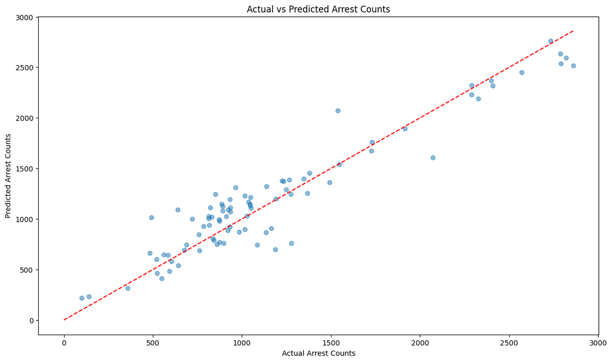

```python
# Filter the DataFrame to include only data after mid 2020
df_since_mid_2020 = df[df['ARREST_DATE'] >= '2020-06-01']

# Identify the top 10 most common offense descriptions
top_offenses = df_since_mid_2020['OFNS_DESC'].value_counts().head(10).index

# Filter the DataFrame to include only these top offenses
df_top_offenses = df_since_mid_2020[df_since_mid_2020['OFNS_DESC'].isin(top_offenses)]

# Feature engineering
# df_top_offenses['YEAR'] = df_top_offenses['ARREST_DATE'].dt.year
# df_top_offenses['MONTH'] = df_top_offenses['ARREST_DATE'].dt.month
df_top_offenses.loc[:, 'YEAR'] = df_top_offenses['ARREST_DATE'].dt.year
df_top_offenses.loc[:, 'MONTH'] = df_top_offenses['ARREST_DATE'].dt.month

# Group the data by offense description, year, and month to count arrests
df_grouped = df_top_offenses.groupby(['OFNS_DESC', 'YEAR', 'MONTH']).size().reset_index(name='ARREST_COUNT')

# One-hot encode the offense descriptions
encoder = OneHotEncoder(sparse_output=False)
offense_encoded = encoder.fit_transform(df_grouped[['OFNS_DESC']])
offense_encoded_df = pd.DataFrame(offense_encoded, columns=encoder.get_feature_names_out(['OFNS_DESC']))

# Combine the encoded features with the original data
df_model = pd.concat([df_grouped[['YEAR', 'MONTH', 'ARREST_COUNT']], offense_encoded_df], axis=1)

# Prepare the feature matrix X and the target vector y
X = df_model.drop('ARREST_COUNT', axis=1)
y = df_model['ARREST_COUNT']

# Split the data into training and testing sets
X_train, X_test, y_train, y_test = train_test_split(X, y, test_size=0.2, random_state=42)

# Create a pipeline for the model
pipeline = Pipeline([
    ('poly', PolynomialFeatures(degree=5)),
    ('scaler', StandardScaler()),
    ('regressor', SGDRegressor(penalty='l2', alpha=0.01, max_iter=1000, tol=1e-3, random_state=42))
])

# Train the model
pipeline.fit(X_train, y_train)

# Make predictions
y_pred = pipeline.predict(X_test)

# Evaluate the model
mse = mean_squared_error(y_test, y_pred)
print(f'Mean Squared Error: {mse}')

# Visualize the predictions vs actual values
plt.figure(figsize=(14, 8))
plt.scatter(y_test, y_pred, alpha=0.5)
plt.plot([0, max(y_test)], [0, max(y_test)], color='red', linestyle='--')
plt.xlabel('Actual Arrest Counts')
plt.ylabel('Predicted Arrest Counts')
plt.title('Actual vs Predicted Arrest Counts')
plt.show()
```

If our model is accurate, all the scattered points on the above graph should lie on the red line. That would mean that when the model predicts 1500 arrest counts that there are indeed 1500 actual arrest counts. So we want a strong linear relationship.

Our null hypothesis is then that the correlation coefficient is zero. Lets find the p value and correlation coefficient using `pearsonr()`. The [pearsonr](https://docs.scipy.org/doc/scipy/reference/generated/scipy.stats.pearsonr.html) function from the scipy.stats module calculates the Pearson correlation coefficient and the corresponding p-value for testing non-correlation.

```python
# Calculate the Pearson correlation coefficient and p-value
correlation_coefficient, p_value = pearsonr(y_test, y_pred)

# Output the results
print(f'Pearson Correlation Coefficient: {correlation_coefficient}')
print(f'P-value: {p_value}')

# Interpret the p-value
alpha = 0.05
if p_value < alpha:
    print("Reject the null hypothesis. There is a significant linear relationship between predicted and actual values.")
else:
    print("Fail to reject the null hypothesis. There is no significant linear relationship between predicted and actual values.")
```

```
Pearson Correlation Coefficient: 0.951202992499021
P-value: 1.1612396458739002e-44
Reject the null hypothesis. There is a significant linear relationship between predicted and actual values.
```

This suggests that we do indeed have a linear relationship between our predicted and actual values.

NOTE: Our model is still degree 5, non linear, but the plot of predictions vs. actual values is almost linear as suggested by the pearson correlation coefficient of 0.9512. This is good.

The p-value is almost zero which means we reject the null hypothesis of there being no correlation.

Now that we have fit the model to the current data, lets see what predictions it makes up through 2026 for each type of crime.

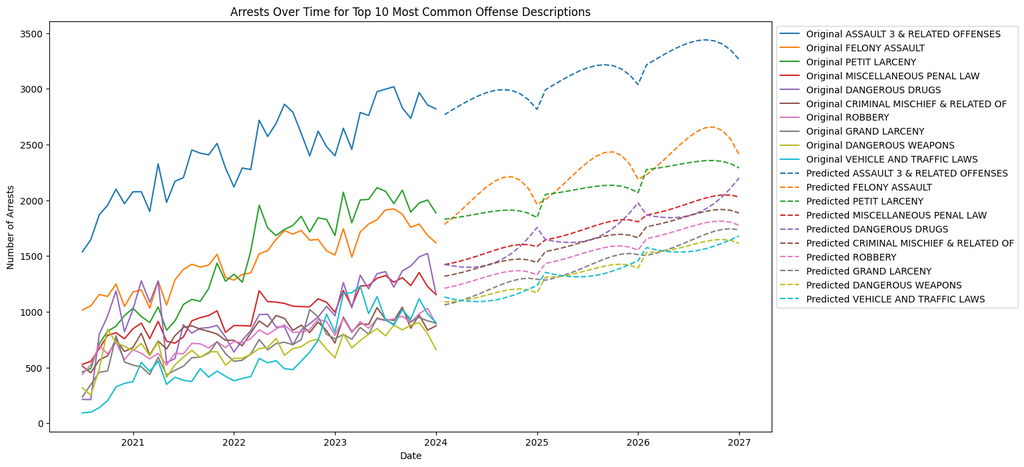

```python
# Prepare to predict future data
last_year = df_model['YEAR'].max()
last_month = df_model['MONTH'].max()

# Extend the data to predict future arrest rates up to December 2024
future_years = []
future_months = []

for i in range(1, 67):  # 67 to account for months from mid-2020 to end of 2026
    next_month = last_month + i
    next_year = last_year + (next_month - 1) // 12
    future_years.append(next_year)
    future_months.append((next_month - 1) % 12 + 1)
    if next_year == 2026 and (next_month - 1) % 12 + 1 == 12:
        break

future_dates = pd.DataFrame({'YEAR': future_years, 'MONTH': future_months})
future_dates = pd.concat([future_dates]*len(top_offenses), ignore_index=True)
future_dates['OFNS_DESC'] = np.repeat(top_offenses, len(future_dates) // len(top_offenses))

# One-hot encode the future offense descriptions
future_offense_encoded = encoder.transform(future_dates[['OFNS_DESC']])
future_offense_encoded_df = pd.DataFrame(future_offense_encoded, columns=encoder.get_feature_names_out(['OFNS_DESC']))

# Combine the encoded features with the future data
future_model = pd.concat([future_dates[['YEAR', 'MONTH']], future_offense_encoded_df], axis=1)

# Predict future arrest counts
future_predictions = pipeline.predict(future_model)

# Combine future predictions with dates and offense descriptions
future_dates['ARREST_COUNT'] = future_predictions

# Plot the original data
plt.figure(figsize=(14, 8))
for offense in top_offenses:
    data = df_grouped[df_grouped['OFNS_DESC'] == offense]
    plt.plot(data['YEAR'] + data['MONTH'] / 12, data['ARREST_COUNT'], label=f'Original {offense}')

# Plot the predicted future data
for offense in top_offenses:
    data = future_dates[future_dates['OFNS_DESC'] == offense]
    plt.plot(data['YEAR'] + data['MONTH'] / 12, data['ARREST_COUNT'], '--', label=f'Predicted {offense}')

plt.xlabel('Date')
plt.ylabel('Number of Arrests')
plt.title('Arrests Over Time for Top 10 Most Common Offense Descriptions')
plt.legend(bbox_to_anchor=(1, 1))
plt.show()
```

### Interpretation: Analysis and Policy Decision

**Based on the analysis, several important insights and conclusions can be drawn:**

1. Impact of External Factors: The significant drop in arrests around 2020, likely due to the COVID-19 pandemic and changes in policing practices such as the end of stop-and-frisk, followed by a subsequent increase, highlights the impact of external factors on crime rates. This underscores the importance of considering broader social and policy changes when analyzing crime data.
2. Consistent Demographic Trends: Arrest trends are consistent across different races, genders, and age groups, which simplifies modeling but underscores the pervasive nature of certain factors affecting crime rates. This suggests that demographic factors alone do not significantly alter the overall trends in arrest rates.
3. Geographic Variations in Crime Types: While arrest rates by borough follow similar trends over time, the types of crimes prevalent in each borough differ. This indicates that localized factors, such as economic conditions, community programs, and policing practices, play a significant role in influencing the types of criminal activity in different areas.

**The findings from our analysis suggest several important implications for policy and decision-making:**

1. Resource Allocation: Understanding the seasonal patterns and specific trends for different types of crimes can help law enforcement agencies allocate resources more effectively. For instance, increasing patrols or community engagement efforts during the summer months for crimes that peak during this period.
2. Targeted Interventions: Policies should be tailored to address the unique trends of different types of crimes. For example, if certain offenses are predicted to rise more rapidly, proactive measures such as targeted education campaigns, stricter enforcement, or community programs can be implemented to mitigate these increases.
3. Pandemic and Policy Effects: The analysis highlights the significant impact of the COVID-19 pandemic and policing policy changes on crime rates. Future policy decisions should consider these effects and aim to balance public health, civil liberties, and effective crime prevention.
4. Predictive Policing: The ability to forecast future crime rates with machine learning models can support predictive policing efforts. By anticipating where and when crimes are likely to occur, law enforcement can take preemptive actions to prevent crimes, thereby enhancing public safety.
5. Community Engagement: Policymakers should engage with communities to address the root causes of crime, informed by the demographic and geographic insights from the data. Community-based programs focusing on at-risk groups can help reduce crime rates over the long term.

In conclusion, our machine learning model and data analysis provide valuable insights into the trends and patterns of crime in New York City. By leveraging these findings, policymakers and law enforcement agencies can make informed decisions to enhance public safety and effectively allocate resources. As we look to the future, continuous monitoring and updating of the model with new data will be crucial to adapting to evolving crime dynamics and ensuring the efficacy of interventions.

### Fun Further Exploration

Our model does a good job of predicting the data. However, we used a pretty basic degree 5 polynomial model. Now that we have covered the basics, we will experiment a little. In this section we try implementing a model not covered in class but one that is considered much more suitable for forecasting trends. It is called an [LSTM (Long-Short Term Memory)](https://www.geeksforgeeks.org/deep-learning-introduction-to-long-short-term-memory/).

LSTMs are a type of [recurrent neural network (RNN)](https://www.geeksforgeeks.org/introduction-to-recurrent-neural-network/) specifically designed to learn and remember over long sequences, making them particularly well-suited for time series prediction tasks. Unlike traditional regression models, which predict future values based on linear relationships among features, LSTMs are capable of capturing complex temporal dependencies and patterns in sequential data.

The primary advantage of using LSTM over ridge regression lies in its ability to handle the temporal structure of the data. Ridge regression treats each data point independently and may fail to account for the sequential dependencies inherent in time series data. In contrast, LSTMs maintain a memory of previous inputs through their recurrent connections, allowing them to leverage past information to make more accurate predictions. This makes LSTMs particularly effective for tasks where the order and context of previous observations significantly influence future values.

We'll attempt this by first preparing and normalizing the data for use with an [LSTM model](https://www.tensorflow.org/api_docs/python/tf/keras/layers/LSTM). We first extract the year and month from the arrest dates to group the data accordingly. By aggregating the monthly crime counts, we can analyze trends over time. The 'YEAR_MONTH' values are then converted back to datetime format to facilitate plotting. After handling any missing values by either dropping or filling them, we normalize the 'CRIME_COUNT' values to a range between 0 and 1 using a MinMaxScaler. Normalization is crucial for ensuring that all input features contribute equally to the model's performance, especially for LSTM networks which are sensitive to the scale of input data.

```python
# Extract year and month for grouping
df['YEAR_MONTH'] = df['ARREST_DATE'].dt.to_period('M')

# Group by YEAR_MONTH and count the number of arrests
monthly_crime_counts = df.groupby('YEAR_MONTH').size().reset_index(name='CRIME_COUNT')

# Convert YEAR_MONTH back to datetime for plotting
monthly_crime_counts['YEAR_MONTH'] = monthly_crime_counts['YEAR_MONTH'].dt.to_timestamp()

# Handle missing values if necessary (drop or fill)
monthly_crime_counts = monthly_crime_counts.dropna()

# Normalize the data
scaler = MinMaxScaler(feature_range=(0, 1))
monthly_crime_counts['CRIME_COUNT'] = scaler.fit_transform(monthly_crime_counts[['CRIME_COUNT']])
```

Now we create the dataset required for training the LSTM model. We define a function create_dataset to generate input-output pairs from the time series data, with a specified time step representing the number of previous time steps used to predict the next value. The crime data is converted into a numpy array and reshaped for processing. We then set the time step to 12 (indicating that each prediction is based on the past 12 months of data) and use the function to create the dataset. The data is split into training and test sets, with 80% of the data allocated for training and 20% for testing. Finally, we reshape the input data to match the LSTM input format [samples, time steps, features], preparing it for model training.

```python
# Prepare the data for LSTM
def create_dataset(dataset, time_step=1):
    dataX, dataY = [], []
    for i in range(len(dataset)-time_step-1):
        a = dataset[i:(i+time_step), 0]
        dataX.append(a)
        dataY.append(dataset[i + time_step, 0])
    return np.array(dataX), np.array(dataY)

# Convert the dataframe to a numpy array
crime_data = monthly_crime_counts['CRIME_COUNT'].values
crime_data = crime_data.reshape(-1, 1)

# Set the time step
time_step = 12

# Create the dataset
X, y = create_dataset(crime_data, time_step)

# Split the data into train and test sets
train_size = int(len(X) * 0.8)
test_size = len(X) - train_size
X_train, X_test = X[0:train_size,:], X[train_size:len(X),:]
y_train, y_test = y[0:train_size], y[train_size:len(y)]

# Reshape the input to be [samples, time steps, features] which is required for LSTM
X_train = X_train.reshape(X_train.shape[0], X_train.shape[1], 1)
X_test = X_test.reshape(X_test.shape[0], X_test.shape[1], 1)
```

This next part involves building, training, and evaluating the LSTM model. We construct a sequential LSTM model with two LSTM layers and one dense output layer. The model is compiled with the Adam optimizer and mean squared error loss function. We then train the model using the training data, validating it on the test data, over 100 epochs. After training, the model predicts crime rates for both training and test data. These predictions are then transformed back to the original scale using the inverse of the MinMaxScaler. The actual values for training and test data are also inverted to their original scale. We calculate the Root Mean Squared Error (RMSE) for both training and testing predictions, providing a measure of how well the model has learned and how it performs on unseen data.

```python
# Build the LSTM model
model = Sequential()
model.add(LSTM(50, return_sequences=True, input_shape=(time_step, 1)))
model.add(LSTM(50, return_sequences=False))
model.add(Dense(1))
model.compile(optimizer='adam', loss='mean_squared_error')

# Train the model
model.fit(X_train, y_train, validation_data=(X_test, y_test), epochs=100, batch_size=32, verbose=1)

# Predict the crime rates
train_predict = model.predict(X_train)
test_predict = model.predict(X_test)

# Invert the predictions to the original scale
train_predict = scaler.inverse_transform(train_predict)
test_predict = scaler.inverse_transform(test_predict)

# Invert the actual values
y_train = scaler.inverse_transform(y_train.reshape(-1, 1))
y_test = scaler.inverse_transform(y_test.reshape(-1, 1))

# Calculate RMSE for evaluation
train_rmse = math.sqrt(mean_squared_error(y_train, train_predict))
test_rmse = math.sqrt(mean_squared_error(y_test, test_predict))

print(f'Train RMSE: {train_rmse}')
print(f'Test RMSE: {test_rmse}')
```

[output not shown]

[output cut: 49 more lines]

```
6/6 ━━━━━━━━━━━━━━━━━━━━ 0s 7ms/step - loss: 0.0083 - val_loss: 0.0183
6/6 ━━━━━━━━━━━━━━━━━━━━ 0s 7ms/step - loss: 0.0094 - val_loss: 0.0183
6/6 ━━━━━━━━━━━━━━━━━━━━ 0s 7ms/step - loss: 0.0069 - val_loss: 0.0187
6/6 ━━━━━━━━━━━━━━━━━━━━ 0s 8ms/step - loss: 0.0082 - val_loss: 0.0157
6/6 ━━━━━━━━━━━━━━━━━━━━ 0s 7ms/step - loss: 0.0100 - val_loss: 0.0171
6/6 ━━━━━━━━━━━━━━━━━━━━ 0s 7ms/step - loss: 0.0076 - val_loss: 0.0192
6/6 ━━━━━━━━━━━━━━━━━━━━ 0s 7ms/step - loss: 0.0067 - val_loss: 0.0201
6/6 ━━━━━━━━━━━━━━━━━━━━ 0s 6ms/step - loss: 0.0072 - val_loss: 0.0185
6/6 ━━━━━━━━━━━━━━━━━━━━ 0s 7ms/step - loss: 0.0085 - val_loss: 0.0203
6/6 ━━━━━━━━━━━━━━━━━━━━ 0s 7ms/step - loss: 0.0081 - val_loss: 0.0197
6/6 ━━━━━━━━━━━━━━━━━━━━ 0s 8ms/step - loss: 0.0086 - val_loss: 0.0209
6/6 ━━━━━━━━━━━━━━━━━━━━ 0s 24ms/step
2/2 ━━━━━━━━━━━━━━━━━━━━ 0s 2ms/step
Train RMSE: 2769.0986678302206
Test RMSE: 4529.076101678715
```

In this final part, we'll visualize the results of our model's predictions. We align the training and test predictions with the actual data timeline to ensure accurate plotting. The plot displays the actual crime count data, the training predictions, and the test predictions, allowing us to visually assess the model's performance. Labels and legends are added to the plot for clarity, making it easier to compare the actual data with the model's predictions. This visualization helps in understanding the model's effectiveness in capturing trends and patterns in the crime data over time.

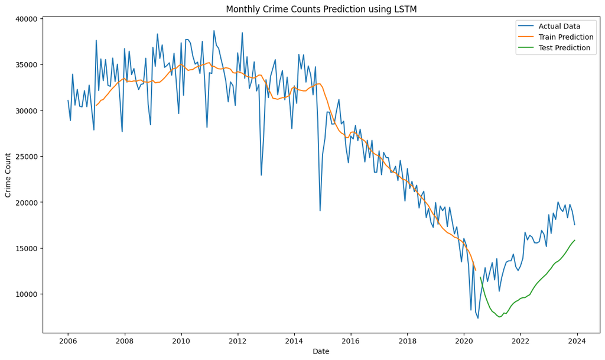

```python
# Plot the results

# Shift the train predictions for plotting
train_predict_plot = np.empty_like(crime_data)
train_predict_plot[:, :] = np.nan
train_predict_plot[time_step:len(train_predict)+time_step, :] = train_predict

# Shift the test predictions for plotting
test_predict_plot = np.empty_like(crime_data)
test_predict_plot[:, :] = np.nan
test_predict_plot[len(train_predict)+(time_step)+1:len(train_predict)+(time_step)+1+len(test_predict), :] = test_predict

# Plot the baseline and predictions
plt.figure(figsize=(14,8))
plt.plot(monthly_crime_counts['YEAR_MONTH'], scaler.inverse_transform(crime_data), label='Actual Data')
plt.plot(monthly_crime_counts['YEAR_MONTH'][time_step:len(train_predict)+time_step], train_predict, label='Train Prediction')
plt.plot(monthly_crime_counts['YEAR_MONTH'][len(train_predict)+(time_step)+1:len(train_predict)+(time_step)+1+len(test_predict)], test_predict, label='Test Prediction')
plt.title('Monthly Crime Counts Prediction using LSTM')
plt.xlabel('Date')
plt.ylabel('Crime Count')
plt.legend()
plt.show()
```